# R Notebook

# 統計學習初論（106-2）作業三 第二題

# (1)

Provide the summary statistics of msong_train.

```r
load(file="data/msong_slhw.rdata")
#defin the summary statistic function
sumds = function(ds) {
  nvariable = ncol(ds)
  varnames = colnames(ds)
  for(i in 1:nvariable) {
    tmp1 = ds[,i]
    #remove NA
    tmp1 = tmp1[!is.na(tmp1)]
    n = length(tmp1)
    mean = mean(tmp1)
    median = median(tmp1)
    sd = sd(tmp1)
    q13 = quantile(tmp1, c(0.25, 0.75))
    min1 = min(tmp1)
    max1 = max(tmp1)
    arow = c(n, mean, median, sd, q13, min1, max1)
    if(i==1) {
      out1 = arow
    } else {
      out1 = rbind(out1, arow)
    }
  }
  rownames(out1) = varnames
  colnames(out1) = c("n", "mean", "median", "sd", "Q1", "Q3", "Min", "Max")
  return(out1)
}
sumds(msong_train)
```

```
         n         mean      median          sd          Q1          Q3         Min         Max
year 10000 1998.1868000 2002.000000   11.019966 1994.000000 2006.000000  1926.00000  2010.00000
x1   10000   43.3271126   44.159280    6.070209   39.836132   47.763818    12.32426    60.91829
x2   10000    1.1985093    8.719690   52.321661  -26.229055   36.323230  -291.66011   254.99489
x3   10000    8.6434885   10.561895   34.648990  -10.767837   29.264367  -188.82244   261.61190
x4   10000    0.9711060   -0.693125   15.870334   -8.422883    8.649355  -106.39015   145.11468
x5   10000   -6.4581155   -6.066075   22.548475  -20.823903    7.675220  -115.47235   154.09470
x6   10000   -9.6376147  -11.085815   12.744388  -18.438495   -2.355105   -68.94057    71.45500
x7   10000   -2.4694622   -2.126850   14.673932  -10.811212    6.460300   -80.66400   172.40268
x8   10000   -1.7809462   -1.638355    7.953511   -6.374542    2.890117   -55.46124    80.47882
x9   10000    3.7668685    3.945825   10.625117   -2.287780    9.978203   -89.67162    67.86026
x10  10000    1.8856856    1.774055    6.495955   -2.432295    6.160525   -26.70307    36.83311
x11  10000   -0.1170781   -0.023260    4.292850   -2.601485    2.487868   -24.56529    23.65410
x12  10000    2.4545137    2.279025    8.242975   -2.655935    7.336325   -46.42630    55.95669
x13  10000   33.7104484   29.095405   22.397000   18.198470   43.714585     0.29826   549.76491
x14  10000 2415.2850226 1989.973190 1695.069508 1304.566253 3015.483785   110.64626 21586.53295
x15  10000 1967.7788832 1695.972455 1229.166685 1129.764350 2509.687338    43.53343 16070.30251
x16  10000 1500.4494553 1230.692730 1044.110775  820.202348 1873.518632    56.88470 19468.51788
x17  10000  911.5853973  816.350790  478.777515  607.986778 1092.359328    32.79177  8624.11333
x18  10000  871.2658655  734.747725  557.496833  489.286000 1107.038922    41.76999  7666.94923
x19  10000  604.9279793  546.527100  315.308493  394.959777  741.714085    25.60591  5278.95403
x20  10000  516.2329857  443.677520  303.125123  320.365612  624.049568    32.58303  5905.05143
x21  10000  396.2758057  352.005630  216.671184  258.026370  479.338035    37.70988  3709.81786
x22  10000  324.2071169  293.574185  162.406688  215.041875  396.294730    37.31956  3222.11855
x23  10000  285.7722003  240.523370  178.885619  167.817145  352.397670    26.76657  2313.36506
x24  10000  294.5213472  266.911260  158.274189  198.191408  352.007782    11.99548  5036.61707
x25  10000   43.4470525   26.555215  120.091330  -12.036922   87.369273 -1169.87939  1278.46897
x26  10000   40.0544845  -49.941145  710.937242 -288.263510  283.489700 -5275.45062  8613.43564
x27  10000  -40.1885044  -38.848035  541.586795 -249.637232  178.612705 -6421.58438  6991.75206
x28  10000  -23.6369413  -22.278125  218.675729 -117.526967   67.760810 -3602.61325  2443.25152
x29  10000   13.0605983    7.626745  159.561742  -61.668827   84.337515 -1485.29391  1253.12491
x30  10000   43.5502220   30.129945  132.856206  -24.043582   95.091675 -1005.40172  1691.79469
x31  10000    7.1706126    4.748565   99.566201  -38.342152   49.709393 -2094.05405  1187.88133
x32  10000   23.7570916   23.687800   72.595193   -7.250960   56.775225  -709.35501  1102.86669
x33  10000   11.0866011    8.020255   74.918761  -23.915078   41.935570  -615.14772  1248.06167
x34  10000   -5.0503928  -10.010350   48.880074  -29.637712   12.160485  -351.50530   793.20146
x35  10000    1.0133177    3.259075   42.232887  -16.533667   20.774015  -479.33066   691.12904
x36  10000   72.7693210   56.796860  106.979861   15.171990  118.023570  -685.27941  1128.24878
x37  10000  -52.8300494  -75.205955  408.915052 -222.796675   80.838237 -4149.79174 10177.22886
x38  10000  121.6458765   80.560045  458.036500  -99.593805  309.122703 -4155.24403  5506.48657
```

[output cut: 37 more lines]

```
x76  10000   -5.6208585   -2.281195   26.219768  -15.068670    7.759755  -248.32263   161.33607
x77  10000  -21.2560359  -57.393565  261.661567 -148.453747   62.922565 -4323.77527  3644.35104
x78  10000   32.8439700   39.513525  144.498321  -30.634710  107.567075 -1725.41083  1373.93798
x79  10000 -103.1469076  -70.165410  185.654187 -159.372895   -6.452630 -3769.35798  1120.62270
x80  10000   26.4687329   27.103930  123.863256  -27.700288   86.105495 -1990.44643  1281.30259
x81  10000   15.9651262    9.287875   32.635625   -2.029592   26.719585  -210.76616   339.58053
x82  10000  -71.8112206  -51.912365  168.659587 -134.901398   13.935095 -2879.88683  1528.98061
x83  10000   42.2867032   28.695925  121.097217  -20.735817   89.053050  -634.30311  1808.80809
x84  10000   38.1246606   33.458770   93.554109   -4.697332   77.185190 -1145.43876   931.34487
x85  10000    0.3625088    0.715770   16.271517   -6.891730    8.620510  -157.65469   219.01800
x86  10000   18.2227208   15.967840  106.474841  -31.239390   67.113285 -1029.05211   852.85366
x87  10000  -25.1016416  -20.607955  169.490071 -103.500440   53.977287 -2481.44438  1309.30450
x88  10000    4.3526904    3.046510   13.117440   -2.449558    9.767093   -65.77490   229.68655
x89  10000   22.4608309    8.799645  184.351427  -58.799795   88.098060 -2380.79779  2881.36422
x90  10000    1.4795032   -0.016505   22.161196   -8.776822    9.802440  -179.77507   241.85549
```

Provide the summary statistics of msong_test.

```r
sumds(msong_test)
```

```
         n          mean      median          sd          Q1           Q3          Min         Max
year 51630 1998.49575828 2002.000000   10.852015 1995.000000 2006.0000000   1927.00000  2010.00000
x1   51630   43.40183549   44.229145    5.962572   39.929720   47.8368225      6.69767    60.27724
x2   51630    1.54519633    8.890255   51.281696  -25.184490   35.9814675   -303.17282   275.04470
x3   51630    8.73156404   10.548425   35.303265  -11.600835   29.9406525   -245.41092   263.00262
x4   51630    1.46375816   -0.319695   16.212757   -8.230815    9.0850150    -89.21770   335.77182
x5   51630   -6.92073021   -6.123600   22.902284  -20.933628    7.6800625   -131.84673   146.91554
x6   51630   -9.13081367  -11.018170   13.038397  -18.168130   -2.1228100    -57.98061   166.23689
x7   51630   -2.44928892   -2.038705   14.496472  -10.825130    6.4569400   -113.11600    83.60267
x8   51630   -1.78887029   -1.746645    7.981406   -6.531265    2.9842700    -57.87199   126.74127
x9   51630    3.84725212    3.889485   10.614668   -2.213935   10.0518950    -72.14212    88.00765
x10  51630    1.97121526    1.866745    6.595403   -2.413148    6.3131425    -37.49147    36.95197
x11  51630   -0.17708238   -0.113990    4.390092   -2.697500    2.4163325    -62.40944    88.02082
x12  51630    2.58773971    2.383270    8.291375   -2.462515    7.3404325    -80.16784    76.36122
x13  51630   34.11927032   29.337760   22.545268   18.461675   44.0658325      0.69803   399.79301
x14  51630 2470.46151955 2036.814180 1761.158842 1330.593548 3086.1168125     59.27500 44023.78920
x15  51630 1991.37698992 1711.733060 1259.105377 1124.319798 2523.3083050     94.39029 20165.90889
x16  51630 1540.09136144 1258.273285 1091.080793  827.783660 1934.1362975     93.51862 23132.37670
x17  51630  915.90806752  821.543940  476.833613  606.870550 1106.9653375     59.95446 10044.83913
x18  51630  893.04855105  750.538350  578.157251  498.638940 1133.8775425     32.04469  9817.27382
x19  51630  608.59038335  545.181800  323.913463  395.058670  748.2854975     32.02656 11901.70515
x20  51630  530.22273337  451.568245  315.659221  324.773685  642.2175950     31.13742  5488.13812
x21  51630  395.35280303  350.179110  213.478838  257.545525  477.2580175     23.75953  5819.18312
x22  51630  332.00638260  296.971855  170.366967  217.460820  403.9577425     32.53027  2696.04952
x23  51630  294.70269116  245.639020  194.334292  169.886433  362.6588400     23.31370  4122.49504
x24  51630  290.46719882  263.099700  151.220204  196.471448  348.1985450      6.50600  5144.07299
x25  51630   42.55851176   27.258130  119.675302  -12.470350   88.3995900  -1313.06128  1624.50320
x26  51630   43.92184298  -44.854630  720.101774 -290.553132  290.9589800 -13390.36069 15155.46690
x27  51630  -47.37900656  -39.789040  543.978736 -253.769052  166.9493450  -9655.09792  9081.10068
x28  51630  -25.05799879  -21.144845  220.109937 -117.943187   67.9130075  -2982.49801  2729.52811
x29  51630   18.05236632   10.615425  162.622648  -57.986232   87.5824800  -1762.62479  1695.30273
x30  51630   43.17741733   29.916430  135.140777  -25.451130   97.8864900  -1336.79355  1835.91230
x31  51630    3.27829707    2.459865   98.441845  -41.036513   47.7321600  -1397.31172  2347.41480
x32  51630   24.46668609   23.506950   72.563098   -6.321583   56.4218650   -910.70598  1051.24794
x33  51630    6.39561782    5.838890   74.022583  -27.320495   38.5608575   -892.94403  2037.03042
x34  51630   -4.40957585   -9.821730   54.035962  -29.116985   12.4202000   -876.30109  1318.86007
x35  51630   -0.73334785    2.558700   43.184664  -18.256485   20.2560950   -684.59286   648.38233
x36  51630   72.03210749   55.835610  107.656118   13.954292  116.7377625   -747.07678  1504.19644
x37  51630  -49.07401597  -73.822190  410.204283 -224.907245   91.5850025  -5922.28074  6748.44496
x38  51630  123.20797044   82.892050  457.861052 -101.422467  312.8202825  -5751.85173  5887.02687
```

[output cut: 37 more lines]

```
x76  51630   -5.95664793   -2.782625   26.555815  -15.588247    7.3186850   -526.29282   304.00001
x77  51630  -22.91176824  -55.621895  269.641146 -149.727890   64.0821250  -6711.60670  5774.76700
x78  51630   27.86092898   36.074460  143.565393  -36.545100  103.3375250  -2025.77816  1577.45007
x79  51630 -105.28662892  -70.766880  205.161879 -163.351457   -6.6907675  -4665.40884  5188.32729
x80  51630   26.66939781   27.130550  122.566341  -28.530648   85.0338375  -3255.30880  2073.74271
x81  51630   15.86358921    9.279585   32.218761   -1.941518   26.4872025   -246.35782   504.32031
x82  51630  -76.99793791  -54.900645  177.740419 -143.866858   12.3226525  -3129.09361  1745.81442
x83  51630   42.60624316   29.508960  126.057675  -21.597855   91.8615925  -1110.46114  1710.52591
x84  51630   39.31054258   34.781505   96.608422   -4.348418   78.8804025  -1744.64651  1734.07969
x85  51630    0.05072489    0.757470   16.230899   -7.012528    8.2787850   -219.61419   169.21415
x86  51630   18.29731738   16.069910  115.244623  -31.828520   68.4007350  -1774.00158  2010.11756
x87  51630  -25.87084471  -21.931495  172.075713 -102.875242   53.1730125  -2854.34680  2032.43111
x88  51630    4.58129531    3.174520   13.573491   -2.515942   10.1176400   -157.34122   244.34180
x89  51630   22.69213292    9.395170  191.839796  -58.742800   87.5553100  -2506.95503  6946.62767
x90  51630    1.38101620    0.054950   22.472760   -8.882680    9.7583450   -381.42443   677.89963
```

# (2)

#### Data preprocess

Shift the outcome variable (year) to have mean zero by subtracting mean of year in the new training dataset. For the remaining feature values, standardize their values to have a mean zero and unit variance. Use the mean year in training data to shift outcome variables in msong_test. Use the mean and variance of features in the new training dataset to standardize corresponding feature values in msong_test.

```r
preprocess_data <- function(msong_train, n){
    x_train = msong_train[1:n,2:ncol(msong_train)]
    y_train = msong_train$year[1:n]
    x_test = msong_test[,2:ncol(msong_test)]
    y_test = msong_test$year
    org_year_mean =  mean(y_train)
    # shift to mean
    y_train = y_train - mean(y_train)
    # x_train <- scale(x_train) fast way to standarize
    # standarize x_train
    x_train_mean = t(apply(x_train, 2, function(x) mean(x, na.rm=TRUE)))
    x_train_sd = apply(x_train, 2, function(x) sd(x, na.rm=TRUE))
    x_train = sweep(x_train, 2, x_train_mean)
    x_train = sweep(x_train, MARGIN=2, x_train_sd,`/`)
    #  standarize x_test
    x_test = sweep(x_test, 2, x_train_mean)
    x_test = sweep(x_test, MARGIN=2, x_train_sd,`/`)
    y_test = y_test - org_year_mean
    return(list(x_train = x_train, y_train = y_train, x_test = x_test,y_test = y_test ))

}
data = preprocess_data(msong_train, 5000)
x_train = data$x_train
y_train = data$y_train
x_test = data$x_test
y_test = data$y_test
```

#### Training process

Train ridge regression, use gradient descend to minimize the loss function.

```r
# RMSE
RMSE <- function(x_data, y_data, w){
    RMSE = 0
    SE = 0
    x_data = as.matrix(x_data)
    y_data = as.matrix(y_data)
    for(t in 1:nrow(y_data)){
       SE =  SE + (y_data[t] - (w %*%  x_data[t,])) **2
    }
    RMSE = sqrt(SE / nrow(x_data))
    return(RMSE)
}
# training function
train <- function(x_train, y_train, lambda = 1, lr = 0.00001, epochs = 300){
    nfeat = ncol(x_train)
    w = rep(0, nfeat)
    lambda = 10 ** lambda
    x_train = as.matrix(x_train)
    # gradient descend
    for(it in 1:epochs){
        w_grad = rep(0, nfeat)
        for(n in 1:nrow(x_train)){
           w_grad =  w_grad - drop( y_train[n]-  w %*% (x_train[n,])) * x_train[n,] + lambda * w
        }
        w = w - lr * w_grad
    }
    result = list(train_RMSE = RMSE(x_train, y_train, w), test_RMSE = RMSE(x_test, y_test, w) )
    return(result)

}
df <- data.frame(M=integer(),
                 Training=double(),
                 Testing=double())

lambdas  = c(-5, -4, -3, -2, -1, 0, 1, 2)
for (i in 1:length(lambdas)){
    result =  train(x_train, y_train, lambda = lambdas[i])
    df <-rbind(df, data.frame(M = lambdas[i], Training= result$train_RMSE, Testing=result$test_RMSE))
}
df
```

| M | Training | Testing |
| --- | --- | --- |
| -5 | 9.358299 | 9.600763 |
| -4 | 9.358326 | 9.600712 |
| -3 | 9.358604 | 9.600206 |
| -2 | 9.362082 | 9.596062 |
| -1 | 9.434145 | 9.608231 |
| 0 | 9.980849 | 9.965681 |
| 1 | 10.708267 | 10.559764 |
| 2 | Inf | Inf |

Learning rate = 0.00001

Iteration 次數 = 300

嘗試的$\lambda$值 從 $10^{-5}$、 $10^{-4}$ … $10^{1}$ 、$10^{2}$，得到training, testing RMSE的結果如上表

可以看出適當的regularization，也就是合適的$\lambda$對於訓練是有幫助的

而當$\lambda$太大時（$\lambda >= 10^{2}$），就train不起來結果發散了

以下為作圖結果，x軸為以10為底的對數結果，y軸為RMSE

```r
plot (x = df$M, y = df$Training, type='o', col='blue', xlab="M", ylab="RMSE")
lines(x = df$M,y = df$Test,type='o' ,col="red")
```

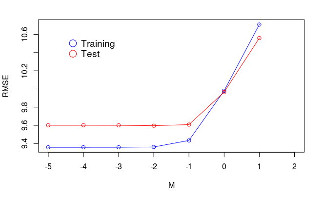

```r
legend("topleft",
  legend = c("Training", "Test"),
  col = c("blue","red"),
  pch = c(1,1),
  bty = "n",
  pt.cex = 2,
  cex = 1.2,
  text.col = "black",
  horiz = F ,
  inset = c(0.1, 0.1))
```

圖形約為U型，RMSE先變小再變大

# 3

Take first 500 rows to generate new training dataset

```r
data = preprocess_data(msong_train, 500)
x_train = data$x_train
y_train = data$y_train
x_test = data$x_test
y_test = data$y_test

df <- data.frame(M=integer(),
                 Training=double(),
                 Testing=double())

lambdas  = c(-5, -4, -3, -2, -1, 0, 1, 2)
for (i in 1:length(lambdas)){
    result =  train(x_train, y_train,lambda = lambdas[i] )
    df <-rbind(df, data.frame(M = lambdas[i], Training= result$train_RMSE, Testing=result$test_RMSE))
}
df
```

| M | Training | Testing |
| --- | --- | --- |
| -5 | 9.222957 | 10.35766 |
| -4 | 9.223005 | 10.35760 |
| -3 | 9.223488 | 10.35702 |
| -2 | 9.228331 | 10.35134 |
| -1 | 9.277509 | 10.30025 |
| 0 | 9.746067 | 10.12186 |
| 1 | 10.956531 | 10.51524 |
| 2 | 11.407882 | 10.80863 |

```r
plot (x = df$M, y = df$Training, type='o', col='blue', xlab="M", ylab="RMSE")
lines(x = df$M,y = df$Test,type='o' ,col="red")
```

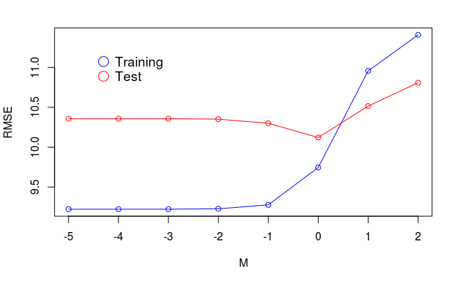

```r
legend("topleft", legend = c("Training", "Test"),   col = c("blue","red"),   pch = c(1,1),   bty = "n", pt.cex = 2,   cex = 1.2,   text.col = "black",   horiz = F ,   inset = c(0.1, 0.1))
```

Take first 1000 rows to generate new training dataset

```r
data = preprocess_data(msong_train, 1000)
x_train = data$x_train
y_train = data$y_train
x_test = data$x_test
y_test = data$y_test

df <- data.frame(M=integer(),
                 Training=double(),
                 Testing=double())

lambdas  = c(-5, -4, -3, -2, -1, 0, 1, 2)
for (i in 1:length(lambdas)){
    result =  train(x_train, y_train,lambda = lambdas[i] )
    df <-rbind(df, data.frame(M = lambdas[i], Training= result$train_RMSE, Testing=result$test_RMSE))
}
df
```

| M | Training | Testing |
| --- | --- | --- |
| -5 | 9.186699 | 9.996829 |
| -4 | 9.186762 | 9.996773 |
| -3 | 9.187394 | 9.996209 |
| -2 | 9.193750 | 9.990715 |
| -1 | 9.260179 | 9.948582 |
| 0 | 9.836077 | 9.990623 |
| 1 | 10.822315 | 10.554785 |
| 2 | 11.143176 | 10.814389 |

```r
plot (x = df$M, y = df$Training, type='o', col='blue', xlab="M", ylab="RMSE")
lines(x = df$M,y = df$Test,type='o' ,col="red")
```

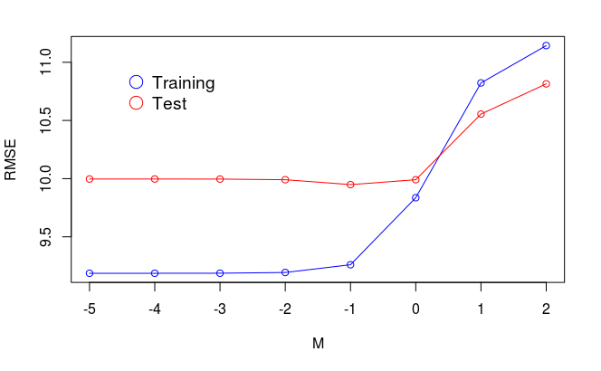

```r
legend("topleft", legend = c("Training", "Test"),   col = c("blue","red"),   pch = c(1,1),   bty = "n", pt.cex = 2,   cex = 1.2,   text.col = "black",   horiz = F ,   inset = c(0.1, 0.1))
```

取500筆跟取1000筆資料的圖形皆相當類似，testing的RMSE皆先變小再提昇

> Testing RMSE

> 500筆最佳：10.12186, 1000筆最佳 9.948582

可以看出較大的sample size的performance較好，1000筆最佳的RMSE跟平均來看都比500筆來的低

若再與第(2)題相比，又可以看出第二題取5000筆的performance又更好

推測在做training時，dataset越大更容易有好的結果，也比較能夠避免overfitting的情況（有多樣化或是極端的測資）

# 4

Shift year to have a mean zero in the new training and testing datasets as in (2). Do not standardize the feature values in this new setting.

此題對於feature不做標準化，結果如下(為了讓訓練順利有做parameter tuning)

```r
x_train = msong_train[1:1000,2:ncol(msong_train)]
y_train = msong_train$year[1:1000]
x_test = msong_test[,2:ncol(msong_test)]
y_test = msong_test$year
org_year_mean =  mean(y_train)
y_train = y_train - org_year_mean
y_test = y_test - org_year_mean
df <- data.frame(M=integer(),
                 Training=double(),
                 Testing=double())

lambdas  = c(-5:2)
for (i in 1:length(lambdas)){
    result =  train(x_train, y_train,lambda = lambdas[i], lr= 10 ** -10, epochs = 100 )
    df <-rbind(df, data.frame(M = lambdas[i], Training= result$train_RMSE, Testing=result$test_RMSE))
}
df
```

| M | Training | Testing |
| --- | --- | --- |
| -5 | 10.72318 | 10.51386 |
| -4 | 10.72318 | 10.51386 |
| -3 | 10.72318 | 10.51386 |
| -2 | 10.72318 | 10.51386 |
| -1 | 10.72318 | 10.51386 |
| 0 | 10.72318 | 10.51386 |
| 1 | 10.72319 | 10.51386 |
| 2 | 10.72328 | 10.51389 |

```r
plot (x = df$M, y = df$Training, type='o', col='blue', xlab="M", ylab="RMSE",ylim=c(10.50, 10.75))
lines(x = df$M,y = df$Test,type='o' ,col="red")
```

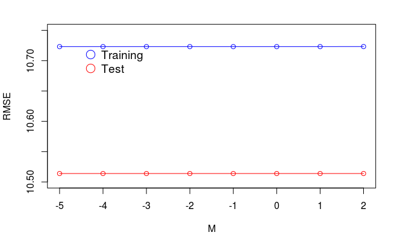

```r
legend("topleft", legend = c("Training", "Test"), col = c("blue","red"),   pch = c(1,1),   bty = "n", pt.cex = 2,   cex = 1.2,   text.col = "black",   horiz = F ,   inset = c(0.1, 0.1))
```

圖可以看出 $\lambda$ 不太影響這次的訓練結果，且performance明顯比有做feaure scaling來的差

> Testing RMSE

> 有 standardize feature 最佳：9.948582, 無 standardize feature 最佳 10.51386

做feaure scaling （將feature標準化），能有效將不同的feaure都放到同一個尺度下做訓練。若沒做此步驟，可能有些feaure數量級特大，其影響力會明顯大於其他feaure（造成bias)，通常更難訓練

# 5

不做任何data preprocess的結果如下

```r
x_train = msong_train[1:1000,2:ncol(msong_train)]
y_train = msong_train$year[1:1000]
x_test = msong_test[,2:ncol(msong_test)]
y_test = msong_test$year
df <- data.frame(M=integer(),
                 Training=double(),
                 Testing=double())

lambdas  = c(-5:6)
for (i in 1:length(lambdas)){
    result =  train(x_train, y_train,lambda = lambdas[i], lr= 10 ** -10, epochs = 100 )
    df <-rbind(df, data.frame(M = lambdas[i], Training= result$train_RMSE, Testing=result$test_RMSE))
}
df
```

| M | Training | Testing |
| --- | --- | --- |
| -5 | 666.6516 | 706.6614 |
| -4 | 666.6516 | 706.6614 |
| -3 | 666.6516 | 706.6614 |
| -2 | 666.6516 | 706.6615 |
| -1 | 666.6516 | 706.6615 |
| 0 | 666.6519 | 706.6618 |
| 1 | 666.6551 | 706.6651 |
| 2 | 666.6869 | 706.6981 |
| 3 | 667.0048 | 707.0282 |
| 4 | 670.2106 | 710.3751 |

[output cut: 2 more lines]

```r
plot (x = df$M, y = df$Training, type='o', col='blue', xlab="M", ylab="RMSE", ylim=c(666, 863))
lines(x = df$M,y = df$Test,type='o' ,col="red")
```

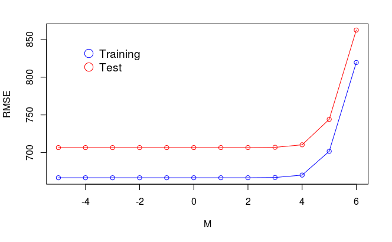

```r
legend("topleft", legend = c("Training", "Test"),   col = c("blue","red"),   pch = c(1,1),   bty = "n", pt.cex = 2,   cex = 1.2,   text.col = "black",   horiz = F ,   inset = c(0.1, 0.1))
```

若年份沒有標準化，其平均約在2000附近，明顯大於其他fearture的平均。在不同的數量級下作訓練，造成了較差的結果，故我們在訓練前應該做feature sacling, 也就是shift the mean of outcome variables to zero。使的每個feature在我們訓練時，大略的能依比例影響我們要找的gradient